## Lecture 10 : Hedge Funds

# Hedge Funds vs. Mutual Funds

*Hedge Fund*

- Transparency: Limited Liability Partnerships that provide only minimal disclosure of strategy and portfolio composition
- Less than 100 investors unless “qualified”

*Mutual Fund*

- Transparency: Regulations require public disclosure of strategy and portfolio composition
- Number of investors is not limited

# Hedge Funds vs. Mutual Funds

*Hedge Fund*

- Investment strategy: Very flexible, funds can act opportunistically and make a wide range of investments
- Often use shorting, leverage, options

*Mutual Fund*

- Investment strategy: Predictable, stable strategies, stated in prospectus
- Limited use of shorting, leverage, options

# Hedge Funds vs. Mutual Funds

*Hedge Fund*

- Compensation structure: Typically charge a management fee of 1-2% of assets and an incentive fee of 20% of profits
- Liquidity: Often have lock‐ up periods, require advance redemption notices, or may be gated

*Mutual Fund*

- Compensation structure: Fees are usually a fixed percentage of assets
- Liquidity: Can move more easily into and out of a mutual fund

# Hedge Fund Strategies

- Directional
  - Bets that one sector or another will outperform other sectors
- Non‐directional
  - Exploit temporary misalignments in relative valuation across securities
  - By one type of security and sell another
  - Market neutral
- Implications for Beta of each strategy?

# Directional Trading

- In contrast to non‐directional, market-neutral strategies, directional funds make large sectoral bets
- Examples: Global Macro funds (e.g. Soros’ Quantum Hedge Fund) make large macro bets on currencies, commodities, sectors.

# Non‐Directional Trading

- Relative value identifies rich vs. cheap based on a model of what prices “should be”
  - Sometimes, economic models (e.g. Royal Dutch/Shell)
  - Often, statistical models
- Statistical Arbitrage
  - Use data mining techniques to uncover systematic pricing patterns
  - Trade on divergence from normal
  - Can involve high frequency trading over short holding periods

# Statistical Arbitrage Example: Pairs Trading

- Find stocks which move together
  - For a given pair, the relative value ($p_{1}/p_{2}$) provide a buy/sell signal
  - High $p_{1}/p_{2}$ implies buy stock 2 and short stock 1
- David Shaw (D.E. Shaw) argues “…human beings don’t like to trade against human nature, which wants to buy stocks after they go up, not down.”
- Long-short strategy is self-financing and market neutral

# Pairs Trading Cookbook

Step A: find stocks which move together

1. For each stock, subtract off mean price, divide by standard deviation (normalized prices),

$$\widetilde{p} = \frac{p - \overline{p}}{\sigma_{p}}$$

2. Calculate sum of squared deviations of normalized prices $(\sum (\widetilde{p}_{1} - \widetilde{p}_{2})^{2})$ across all possible pairs of stocks (N (N-1)/2)
3. Each stock is paired with the stock for which the sum of squared errors is smallest

What is implication for paired stocks $\beta$?

# Pairs Trading Cookbook

# Pairs Trading Cookbook

## Goetzmann, Gatev and Rouwenhorst (2006)

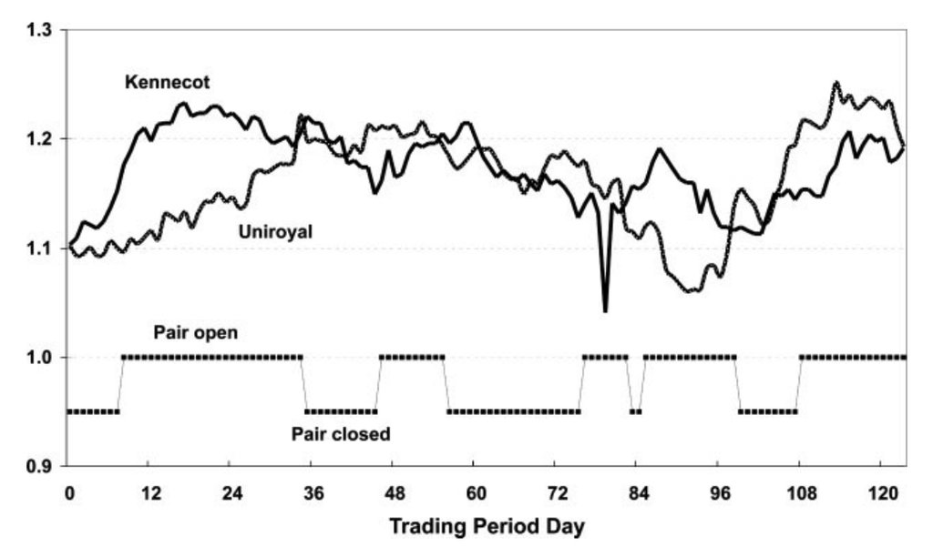

# Pairs Trading Results

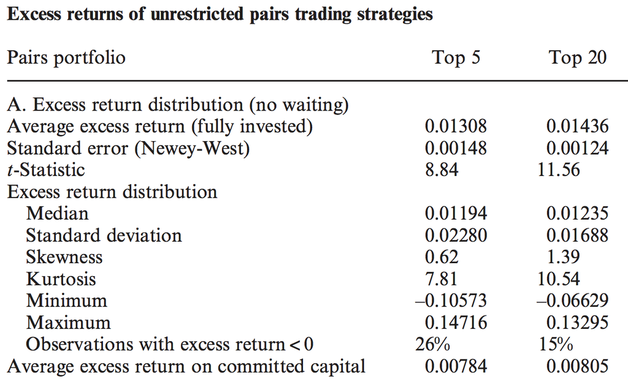

# Pairs Trading Results

- Does pairs trading expose trade to risk factors?
- Market neutrality suggests CAPM alpha, but what about other risks?

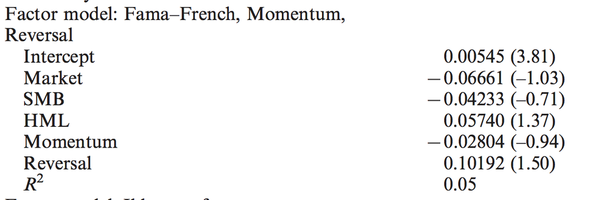

- Coefficients and t-statistics from a five-factor model

# Merger Arbitrage

- Often a long-short strategy strategy which buys target and sells acquirer in announced mergers
- Hedge fund holds event risk
  - Terms not reached
  - Alternate bidders
  - Regulatory approval not granted

# Merger Arbitrage Example

- Tellabs and Ciena merger
  - Both companies involved in fiber‐optic/telecom networks
  - Merged company would be able to compete with larger firms such as Lucent by sharing customer bases, exploiting size
- 1‐for‐1 stock swap announced June 3, 1998
  - Tellabs $64/share
  - Ciena $60/share
  - Upon merger, prices must be equal

# Merger Arbitrage Example

- Another infamous LTCM trade
  - Commit $30M own capital, Borrow $30M @ 6% prime rate
  - Buy 1M Ciena @ $60
  - Sell 1M Tellabs @ $64
  - Earn 4.5% short rebate (interest) on proceeds from short
- What happens?
  - Ciena loses two key customers, shares fall to $15 dollars, deal is abandoned
  - Tellabs shares also decline before position is closed

# Merger Arbitrage Example

- Profits and losses from trade:
  - $30M @ 6% prime rate X (110/360) = ‐$550K
  - $64M short rebate @ 4.5% X (110/360) = $880K
  - Loss on Ciena 1M X ($15‐$60) = ‐$45M
  - Gain on Tellabs ‐1M X ($64‐$42) = $22M
  - TOTAL =‐$22.7M

Total return on committed capital: -75.57%

# Merger Arbitrage: large sample evidence

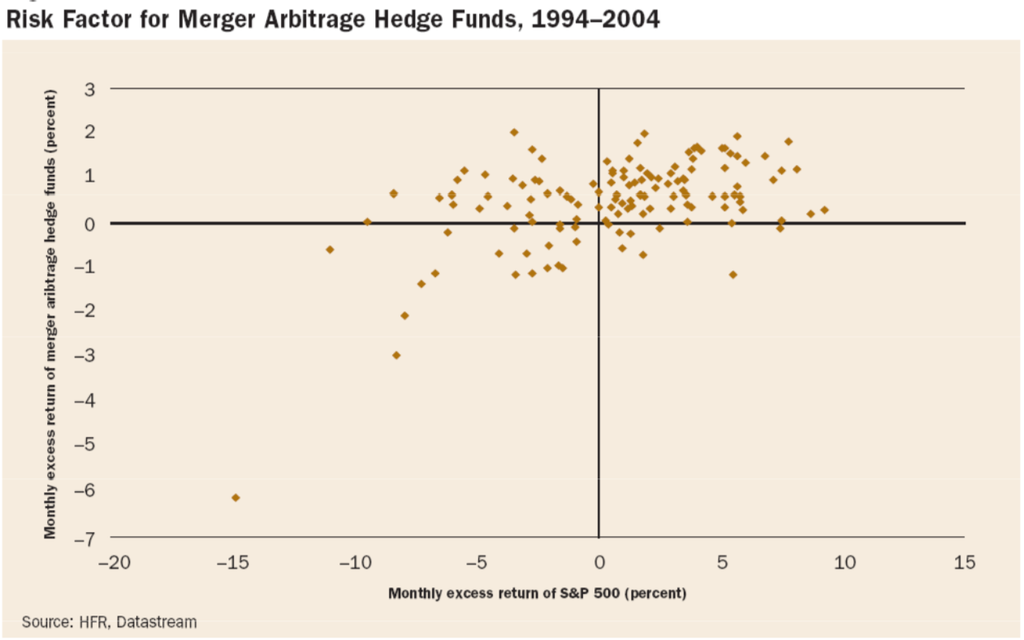

# Merger Arbitrage: large sample evidence

- Merger arb is profitable on average
  - Theory: hedge funds earn premium for insuring shareholders against completion risk

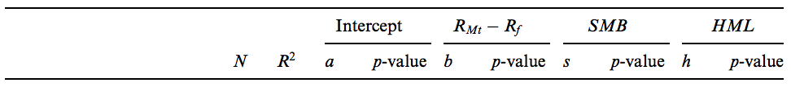

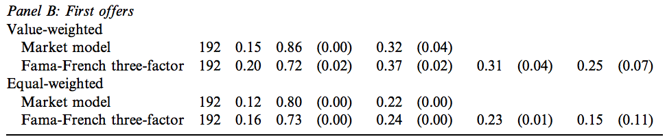

- 72‐86 bps in monthly alpha!

# Hedge Fund Performance Evaluation

- Recall our CAPM-based single factor model

$$r_{i,t} - r_{f} = \alpha_{i} + \beta_{i} (r_{m,t} - r_{f}) + e_{i,t}$$

- Note that for hedge funds, factor loadings are *dynamic*
  - Consider market loading for a long-only market timer
  - If successfull, $\beta$ is only postiive when market returns are high
  - Implies non-linear factor loadings

# Dynamic Performance Evaluation

- Suppose with perfect foresight, we can
  1. Buy market when above risk-free rate of 4%
  2. Hold t-bills when market returns below $r_{f}$

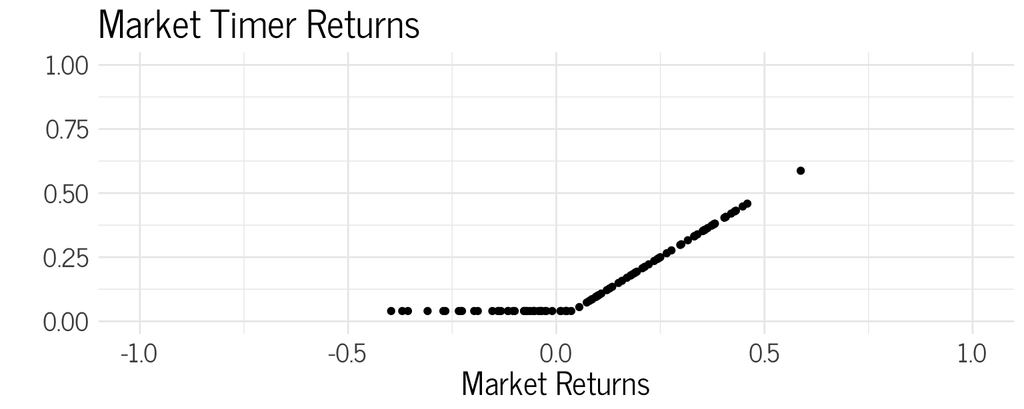

# Dynamic Performance Evaluation

$$r_{p} = \alpha + r_{f} + \beta_{1}(r_{m} - r_{f}) + \beta_{2}(r_{m}-r_{f})^{2} + \epsilon_{p}$$

- $\beta_{2} > 0$ implies market timing ability

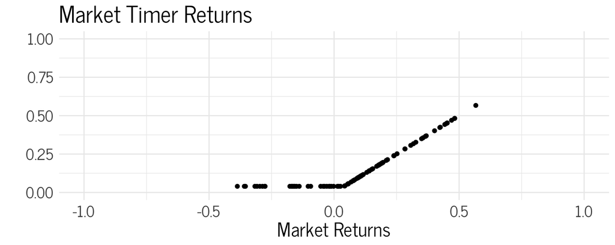

# Dynamic Performance Evaluation

- Alternatively, hedge funds may write out of the money put options that exacerbate downturns

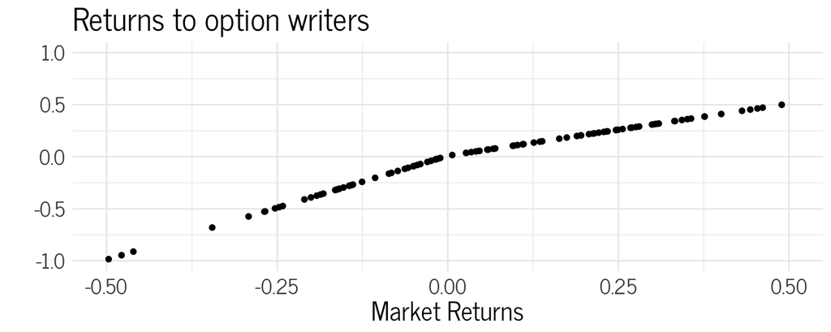

# Dynamic Performance Evaluation

$$r_{p} = \alpha + r_{f} + \beta_{1}(r_{m} - r_{f}) + \beta_{2}(r_{m}-r_{f})^{2} + \epsilon_{p}$$

- $\beta_{2} < 0$ may imply option writing

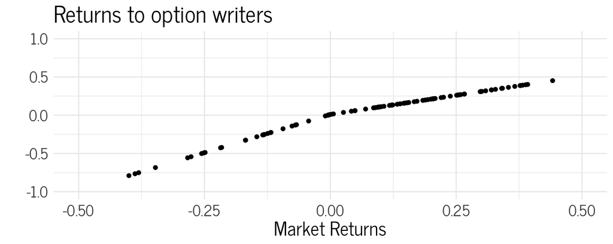

# Non-linear loadings across asset classes

$$\widetilde{r}_{p,t}^{e} = \alpha_{p} + \beta^{+}\max\{\widetilde{r}_{m,t}^{e} , 0\} + \beta^{-}\min\{\widetilde{r}_{m,t}^{e} , 0\} + \epsilon_{p,t}$$

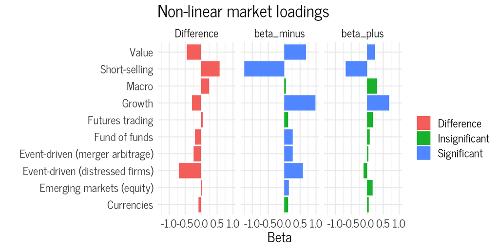